# A Statistical Analysis of Beyoncé and Jay-Z

PowerPug Girls: Alex, Grace, & Jamie

[figure not shown]

# Introduction

In 2016, pop superstar Beyoncé released *Lemonade*, a genre-spanning album that broke records and han a profound cultural impact. While it is is one of Beyoncé’s most critically reviewed albums, *Lemonade* also gained traction due to the tantalising drama of her husband, rapper and producer Jay-Z, cheating on her. In the accomplanying visual album, Beyoncé smashes cars to the tune of “Hold Up”, in celebratory protest of Jay-Z’s infidelity.

One year later, Jay-Z released *4:44*, a spiritual response via album that features Beyoncé as a collaborator. The album openly addresses the rapper’s infidelity, and serves as an symoblic promise to his wife. If only all couples could settle their issues in the recording studio…

The two albums mark a concise shift between the two artists and the rest of their work, thematically, artistically and musically. But what about statistically? Our project works to quantify and qualify the relationship between these two icons by means of a statistical analysis their discography.

# Data

Here are the various sources of our data:

- Lyrics from the `genius` package
- Album charts scraped from OCC database
- Album sales from Wikipedia’s artist discography pages, linked to Billboard magazine’s last published sales record for each artist
- Valence statistics compiled using the `spotifyr` package, which pull from Spotify’s API in bulk
- Critical responses backed by Metacritic scores, which aggregate a variety of publication reviews

# Lyric Analysis

For the text analysis of the lyrics, our key questions of interest were: How do the lyrics of Beyoncé songs differ from *Lemonade*? How do the lyrics of Jay-Z songs differ from *4:44*? But, progressing into our analysis, we quickly realised that text analysis is not entirely appropriate to songs, nor is particularly insightful for either of these artists. So, the analysis took on a different purpose: what information can be gleaned, at all, from a text analysis of Beyoncé and Jay-Z songs, and *Lemonade* and *4:44*? And what information is lost in a text analysis?

## Beyoncé

Beyoncé is up first. The two visualisations below show the 20 most frequent words across Beyoncé’s discography and in *Lemonade* specifically.

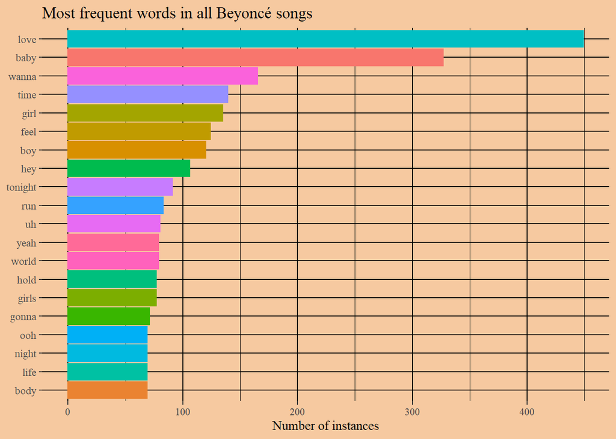

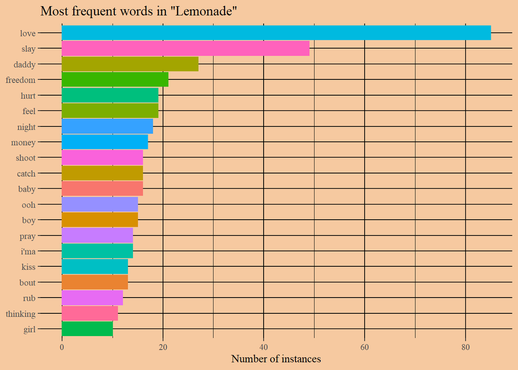

There are many themes central to Beyoncé’s discography and to *Lemonade* that do not appear in the word frequency visualisations. Most notably, her focus on pride and reclaiming of her Black heritage is not visible. This theme can be readily interpreted from the music and visual accompaniments of *Lemonade*. Text analysis does not offer us the full picture, in this instance.

## Jay-Z

Next up is Jay-Z. The two visualisations below show the 20 most frequent words across Jay-Z’s discography and in *4:44* specifically.

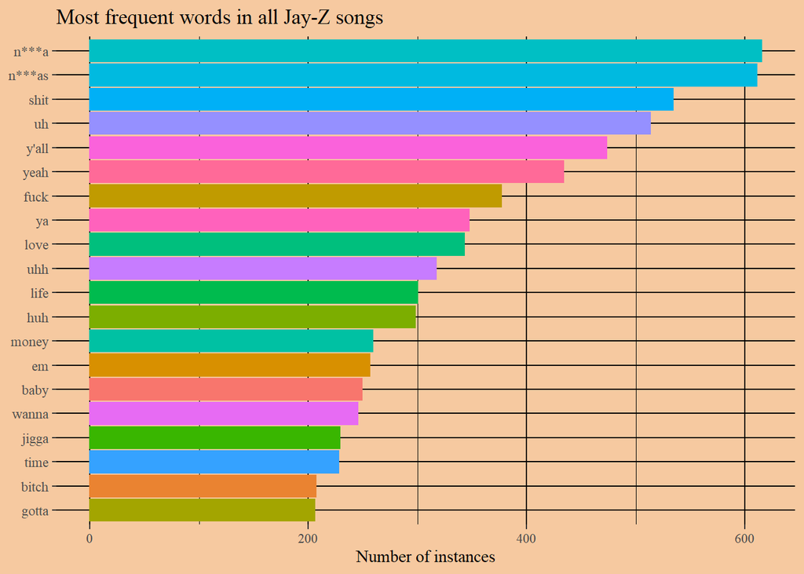

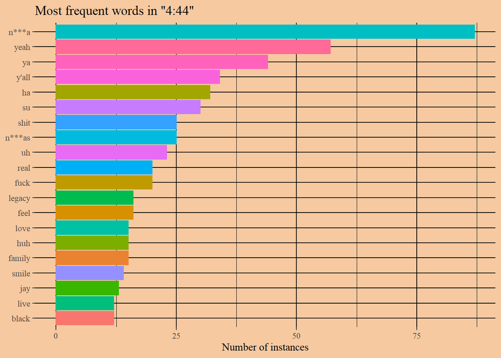

Before addressing the differences between the two, it is important to acknowledge the presence of stop words in the visualisations. Early in the wrangling process, we removed stop words using the stop_words dataset built into R. And yet, 8 of the 20 most frequent words in Jay-Z songs are stop words, vocalisations like “uh” and exclamations like “yeah”. The default stop words package seems to have an inflexible range. Maybe, words like “y’all” provide a cultural context, so are not removed. More likely, the stop word dataset is intended for literatum not music. Still, the implications of such a specification makes the cultural center of their text analysis eurocentric.

Both summaries of Jay-Z songs also show that his songs contain many expletives. This is noteworthy compared to Beyoncé, who does not often use curse words. But, we cannot necessarily prescribe a difference in theme or meaning from this text analysis. Instead, the confounding variable is that their music belongs to different genres. Beyoncé is not a rap artist; Jay-Z is. Within the framework of rap, a field of literature with a developing body of work, I question whether these expletives are stop words or not. Certainly, in comparison with other genres of music, they are exceptional. But, in comparison with other rap music, this is not particularly noteworthy. The n-word also has a unique cultural role in rap music that the visualisation reflects. The n-word and the plural are the two most frequent words in Jay-Z’s music. Again, I do not attribute this to Jay-Z in particular, but to the genre of rap.

And, just like with Beyoncé’s songs, text analysis is uniquely inadequate for rap music. The meaning, style and emotion conveyed lie in the sound.

Regardless of these restrictions, looking past the stop words in the reference of rap music, differences between the set and subset of Jay-Z’s music appear. *4:44*, compared to all Jay-Z songs, touches on themes related to Jay-Z’s infamous infidelity: “family” and “legacy”. Just like with Beyoncé’s music, however, such an ascription is faulty; the song “Legacy” in *4:44* contains “legacy” 16 times.

# Chart Analysis

For the charts analysis of the albums, we wanted to know how the evolution of chart performance for two halves of the biggest musical duo in the world. How do their chart performances compare to each other and is there a moment of synchrony for both *Lemonade* and *4:44*? Progressing into our analysis, we found that Beyoncé performs better on the charts and that despite the artists’ dynamite success in the last 10 years, the chart performances fail to reflect that. So what caused this to happen?

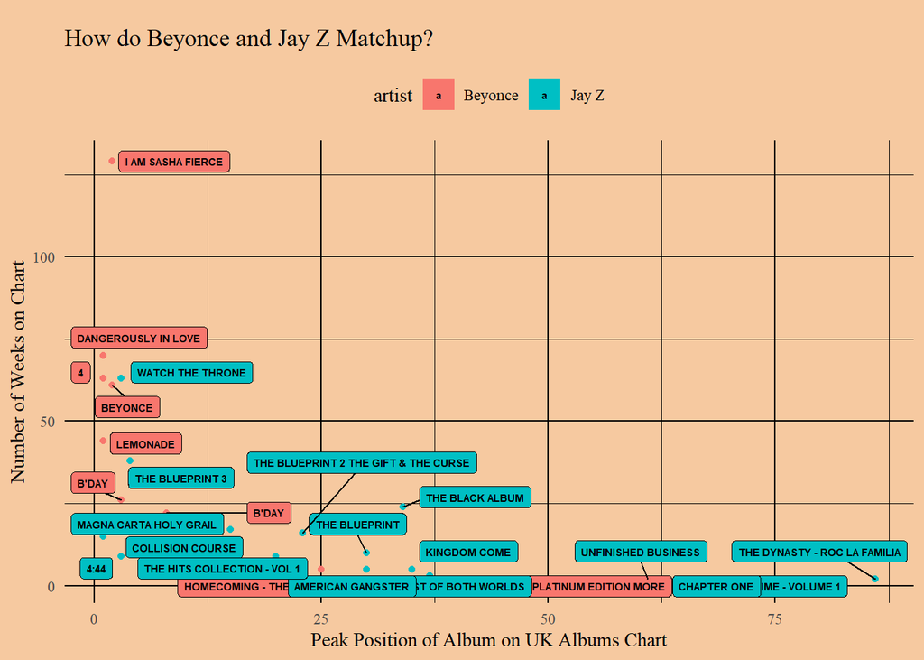

Something we can see from this chart is that Beyoncé fares better in album performance between the two. While Beyoncé is a superstar, her success can be related to her pop genre music and previous work in Destiny’s Child. Beyoncé is a singer in a much more mainstream and commercialized genre of music than Jay Z is. Even though Jay Z may not seem to be as successful in album sales as Beyoncé, he is a rapper and hip-hop has not been treated in the same regard as pop music has.

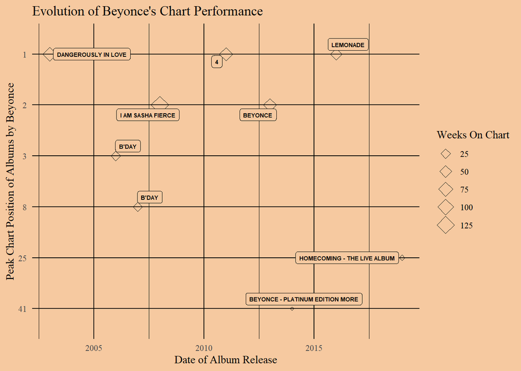

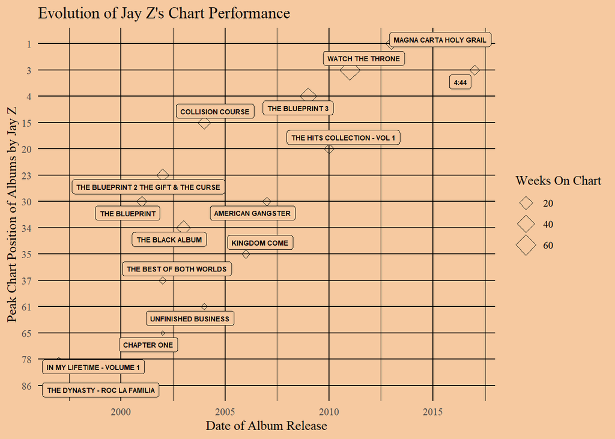

This visualization shows the evolution of Jay Z’s chart performance. While the visualization shows that Jay Z has been on an upward trend, I’d like to note that this is not reflective of his success and fame. As a hip-hop artist, Jay Z would not fare well against pop music counterparts, especially because hip-hop has only become more mainstream in recent years. Another thing to note is that Jay Z almost exclusively released his music on his own streaming service, Tidal. He only released music on Spotify and Apple Music years later. This might affect how well his album performs on charts, despite his immense popularity.

# Sales Analysis

As a disclaimer, album sales are difficult to assess during the streaming era. The below sales numbers are all pulled from Billboard, and they reflect U.S. sales only. All Jay-Z sales below are as of June 2018, and the below numbers reflect streaming numbers converted to physical sales, where 1250 streams equates to 1 album sale. All Beyoncé sales are as of December 2016 except for *Lemonade*, which is pulled from January 2017.

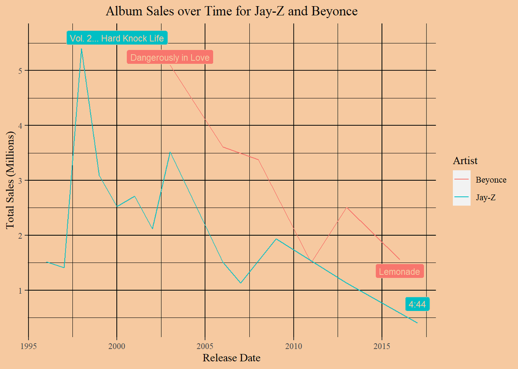

Both artists peaked early in their career, with Jay-Z’s third album *Vol. 2… Hard Knock Life* representing a career high, and Beyoncé’s first album *Dangerously in Love* reflecting her highest single album sales. Naturally, album sales are biased toward older albums, as they have been available to consumers for longer, explaining the negative trend for both artists. Both artists had mid-career resurgence albums. For Jay-Z, it was 2003’s *The Black Album*, and for Beyonce, it was 2013’s *Beyoncé*. The Carters’ most recent releases both present challenges in evaluation. Jay-Z’s commitment to the less-used Tidal streaming service hurt his adjusted sales for 2017’s *4:44*, the lowest selling album of his career. *Lemonade* was initially released as a visual album on Tidal, not being added to Spotify or Apple Music until years later (not reflected in these sales), and the album had been available for less than a year. To put it in perspective, *Lemonade* broke 485,000 adjusted sales in its first week, bolstered by 115 million Tidal streams, a record high streaming number for a female artist.

A statistic called valence exists in Spotify’s API, reflecting the “musical positivity” conveyed by a song. Higher valence numbers correspond to more positive sound, while lower valence numbers correspond to more negative sound. Valence is measured on a scale from 0 to 1, and the plots essentially reflect the density of an album in terms of different valence numbers.

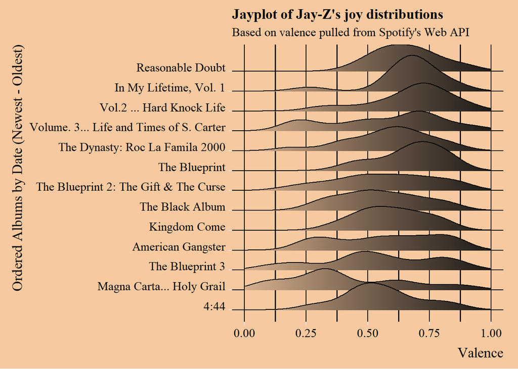

Examining Jay-Z’s career discography, a general trend exists of higher valence peaks early in his career. As his career has progressed, the albums are generally more balanced across the valence spectrum, with less dramatic peaks.

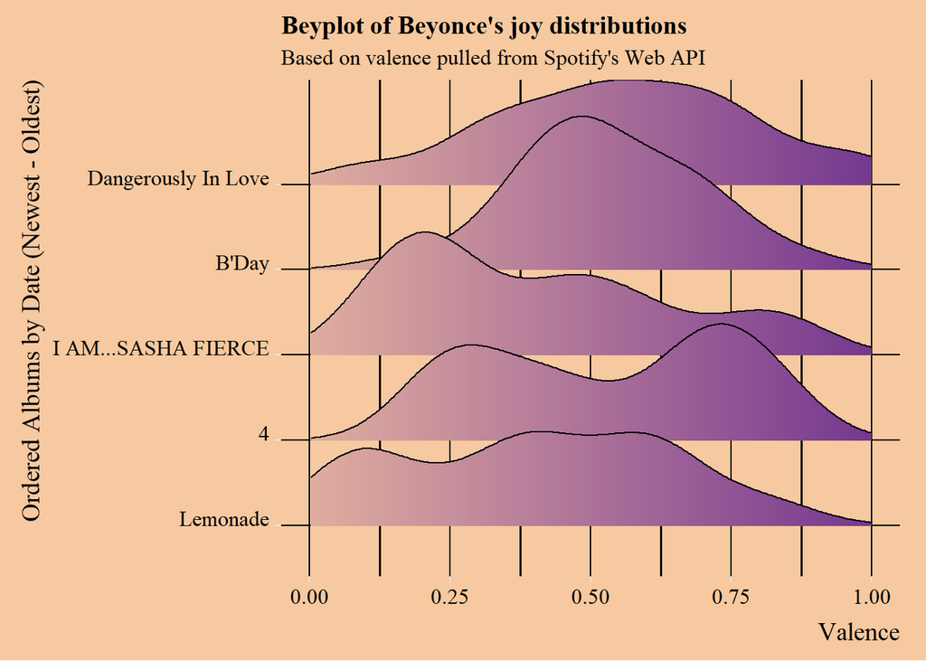

Beyonce’s plots have been more balanced throughout the valence spectrum throughout her career, with peaks usually occurring near the middle. Unsurprising since it covers themes of adultery, *Lemonade* has considerably fewer tracks in the high valence end of the spectrum and a far greater fraction of tracks near 0 than Beyonce’s other studio albums. Important to note, Beyoncé’s eponymous album is omitted from this plot, as it was not available with Spotify’s API statistics.

# Conclusion

Overall, we found a downward trend in sales performances for both artists, a steady trend in chart performance for Beyoncé, and an upward trend in chart performances for Jay-Z. However, we have three things to note. As mentioned, sales data is extremely difficult to acquire in the streaming age. Chart data functions in the same way. With the use of Tidal as a streaming service and album release platform for both artists, it is difficult to assess through charts and sales data on whether or not the duo is successful.

We say they are. There is an overwhelming number of sources that point to *Lemonade* being Beyoncé’s most critically acclaimed album, and *4:44* may be Jay-Z’s best reviewed project of the last decade . Since the release of their two respective and connected albums, the pair has released a collaborative album and completed another critically acclaimed world tour. We believe that Jay-Z and Beyoncé have been on the rise and charts and sales data are not complete depictions of how successful they are or will continue to become.

At the end of the day, Jay-Z and Beyoncé are the world’s most influential musical couple, which charts and sales cannot fully capture. However, the synchrony between the two artists, both lyrically and musically, further bolsters their legacies and is a major component of their continued success.

Thanks for reading!

[figure not shown]